# Untitled

2024311134 안세민

2024-12-12

**Packages**

```r
library(MASS)
library(dplyr)
library(survival)
library(reshape2)
library(ggplot2)
```

**Data**

```r
data <- read.csv("/Users/semin/Desktop/YONSEI/Lecture/2024_2/STA9050_응용통계학특수문제1/기말대체과제/real_data/mimic3_final.csv")
str(data)
```

```
## 'data.frame':    8923 obs. of  12 variables:
##  $ futime                            : num  332.4 33.9 57.7 195.4 27.4 ...
##  $ Glucose                           : num  55.4 48 40.8 52.5 76.7 ...
##  $ Heart.Rate                        : num  105 113 119 124 100 ...
##  $ Height                            : num  82.4 80.5 70.3 78.3 103.1 ...
##  $ Mean.blood.pressure               : num  73.9 68 73.9 70.5 86.1 ...
##  $ Oxygen.saturation                 : num  99 98.3 98.1 93.2 98.2 ...
##  $ Respiratory.rate                  : num  15.4 18.8 13.9 18.6 16 ...
##  $ Temperature                       : num  36.5 36.8 36.6 37.2 37 ...
##  $ Weight                            : num  59.4 89.2 64.9 92.2 81.6 ...
##  $ Glascow.coma.scale.eye.opening    : int  0 0 1 0 2 0 0 0 0 0 ...
##  $ Glascow.coma.scale.verbal.response: int  0 1 0 1 2 1 1 2 2 1 ...
##  $ delta                             : int  0 0 0 0 0 0 0 0 0 0 ...
```

```r
table(data$Glascow.coma.scale.eye.opening)
```

```
##
##    0    1    2    3    4    5
## 1873 6024  213  807    5    1
```

```r
table(data$Glascow.coma.scale.verbal.response)
```

```
##
##    0    1    2    3    4    5    6    7
## 2803 4934  558  469  122   30    5    2
```

```r
table(data$delta)
```

```
##
##    0    1
## 8022  901
```

```r
#data <- data %>%
#  filter(Glascow.coma.scale.eye.opening %in% c(1, 2, 3, 4)) %>%
#  filter(Glascow.coma.scale.verbal.response %in% c(1, 2, 3, 4, 5))

#table(data$Glascow.coma.scale.eye.opening)
#table(data$Glascow.coma.scale.verbal.response)
#table(data$delta)

data <- data %>% select(-Glascow.coma.scale.eye.opening, -Glascow.coma.scale.verbal.response)

remove_outliers_sd <- function(data, col, n = 3) {
  mean_value <- mean(data[[col]], na.rm = TRUE)
  sd_value <- sd(data[[col]], na.rm = TRUE)
  data <- data %>% filter(data[[col]] >= (mean_value - n * sd_value) & data[[col]] <= (mean_value + n * sd_value))
  return(data)
}

# 사용 예시'
data <- remove_outliers_sd(data, col = "futime", n = 3)
data <- remove_outliers_sd(data, col = "Glucose", n = 3)
data <- remove_outliers_sd(data, col = "Heart.Rate", n = 3)
data <- remove_outliers_sd(data, col = "Height", n = 3)
data <- remove_outliers_sd(data, col = "Mean.blood.pressure", n = 3)
data <- remove_outliers_sd(data, col = "Oxygen.saturation", n = 3)
data <- remove_outliers_sd(data, col = "Respiratory.rate", n = 3)
data <- remove_outliers_sd(data, col = "Temperature", n = 3)
data <- remove_outliers_sd(data, col = "Weight", n = 3)

result <- data.frame(
  Mean = round(sapply(data, function(x) mean(x, na.rm = TRUE)), 4),
  SD = round(sapply(data, function(x) sd(x, na.rm = TRUE)), 4)
)

# 결과 출력
print(result)
```

```
##                         Mean       SD
## futime              121.9664 123.3057
## Glucose              59.2178   8.5157
## Heart.Rate          134.1038  25.1612
## Height               85.7940  11.9767
## Mean.blood.pressure  78.8639   9.0080
## Oxygen.saturation    97.0305   1.5711
## Respiratory.rate     18.9253   3.3357
## Temperature          37.0008   0.4841
## Weight               83.7651  20.7966
## delta                 0.1005   0.3007
```

```r
delta1 <- data %>% filter(delta == 1)
delta0 <- data %>% filter(delta == 0)

summary(delta1$Glucose)
```

```
##    Min. 1st Qu.  Median    Mean 3rd Qu.    Max.
##   34.81   53.61   58.91   59.45   65.33   86.61
```

```r
summary(delta0$Glucose)
```

```
##    Min. 1st Qu.  Median    Mean 3rd Qu.    Max.
##   31.88   53.20   58.44   59.19   64.47   87.15
```

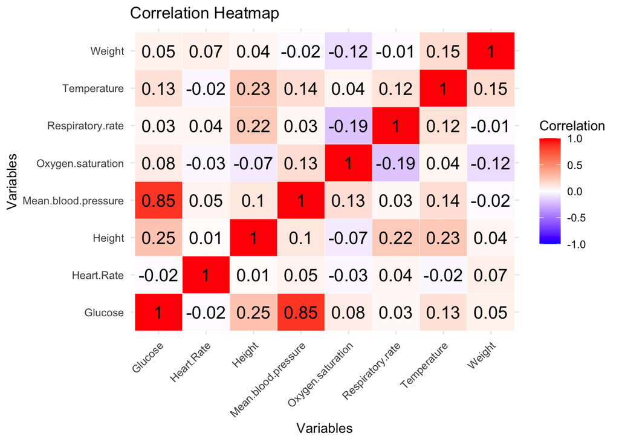

```r
correlation_data <- data %>%
  select(Glucose, Heart.Rate, Height, Mean.blood.pressure, Oxygen.saturation,
         Respiratory.rate, Temperature, Weight)
cor_matrix <- cor(correlation_data, use = "complete.obs")
# 상관계수 행렬 변환
cor_data <- melt(cor_matrix)

ggplot(cor_data, aes(x = Var1, y = Var2, fill = value)) +
  geom_tile(color = "white") +
  geom_text(aes(label = round(value, 2)), color = "black", size = 5) +  # 상관계수 표시
  scale_fill_gradient2(low = "blue", mid = "white", high = "red", midpoint = 0,
                       limit = c(-1, 1), space = "Lab", name = "Correlation") +
  theme_minimal() +
  theme(axis.text.x = element_text(angle = 45, vjust = 1, hjust = 1)) +
  labs(x = "Variables", y = "Variables", title = "Correlation Heatmap")
```

```r
table(data$delta)
```

```
##
##    0    1
## 7323  818
```

futime: ICU 입원과 퇴원 시점 간의 기간(정확한 퇴원 시간이 제공되지 않는 경우 마지막 기록된 점검 시간까지의 기간)(시간 단위) Glucose: 혈액 내 포도당 농도를 측정한 혈당 수치(단위: mg/dL 또는 mmol/L). Heart.Rate: 분당 심박수(bpm). Height: 환자의 키(단위: cm). Mean.blood.pressure: 한 번의 심박 주기 동안의 평균 동맥압(단위: mmHg). Oxygen.saturation: 혈액 내 총 헤모글로빈 대비 산소가 포화된 헤모글로빈의 비율(%). Respiratory.rate: 분당 호흡 수(단위: 호흡/분). Temperature: 환자의 체온(단위: °C). Weight: 환자의 체중(단위: lbs). Glascow.coma.scale.eye.opening: 글래스고 혼수 척도의 눈뜨기 반응 점수(자발적 또는 자극에 의한 눈뜨기를 측정, 범위: 1~4). Glascow.coma.scale.verbal.response: 글래스고 혼수 척도의 언어 반응 점수(말하거나 소리를 낼 수 있는 능력을 평가, 범위: 1~5). delta: 정확한 퇴원 시간이 기록된 경우 1, 그렇지 않은 경우 0.

```r
fit <- coxph(Surv(futime, delta) ~ Glucose + Heart.Rate + Height + Oxygen.saturation + Respiratory.rate + Temperature + Weight , data = data)

true_beta <- summary(fit)$coefficients[, 1]
true_beta <- sprintf("%.4f", true_beta)
data <- list(data)
```

**ncc and weighted cox**

```r
nested_sampling <- function(data, iter, num_controls_per_failure) {
  sampled_datasets <- list()

  for (i in 1:iter) {
    # 데이터 복사 및 초기화
    sampling_data <- as.data.frame(data[[i]])
    sampling_data$index <- 1:nrow(sampling_data)
    sampling_data$Glucose <- NA           # 모든 관측치의 Glucose을 NA로 초기화
    sampling_data$case <- 0          # 사례 여부를 나타내는 변수 초기화 (0: 대조군, 1: 사례)
    sampling_data$weight <- 0        # 가중치 초기화

    # 사건(event) 인덱스 찾기
    event_indices <- which(sampling_data$delta == 1)

    for (j in seq_along(event_indices)) {
      case_index <- event_indices[j]
      t_i <- sampling_data$futime[case_index]

      # 시간 t_i에서의 위험 집합 (futime >= t_i)
      risk_set_indices <- which(sampling_data$futime >= t_i)
      risk_set_indices <- setdiff(risk_set_indices, case_index)  # 사례 제외

      total_controls <- length(risk_set_indices)  # 전체 위험 집합 내 대조군 수

      # 대조군 샘플링
      if (total_controls >= num_controls_per_failure) {
        sampled_controls <- sample(risk_set_indices, num_controls_per_failure, replace = FALSE)
        weight_controls <- total_controls / num_controls_per_failure  # 대조군 가중치
      } else if (total_controls > 0) {
        sampled_controls <- risk_set_indices
        weight_controls <- 1  # 대조군이 충분하지 않은 경우 가중치 설정
      } else {
        next  # 대조군이 없는 경우 다음 사건으로 이동
      }

      # 사례와 대조군의 Glucose 값 설정
      indices <- c(case_index, sampled_controls)
      sampling_data$Glucose[indices] <- data[[i]]$Glucose[indices]

      # 사례 및 대조군 플래그 설정
      sampling_data$case[case_index] <- 1
      sampling_data$case[sampled_controls] <- 0

      # 가중치 설정
      sampling_data$weight[case_index] <- 1  # 사례의 가중치
      sampling_data$weight[sampled_controls] <- weight_controls  # 대조군의 가중치
    }

    sampled_datasets[[i]] <- sampling_data
  }

  return(sampled_datasets)
}

weighted_coxph <- function(sampled_data) {
  beta_estimates <- matrix(NA, nrow = length(sampled_data), ncol = 7)
  se_estimates <- matrix(NA, nrow = length(sampled_data), ncol = 7)

  for (i in 1:length(sampled_data)) {
    case_control_data <- sampled_data[[i]]
    if (nrow(case_control_data) > 0 && length(unique(case_control_data$case)) > 1) {
      cox_model <- tryCatch(
        coxph(Surv(futime, delta) ~ Glucose + Heart.Rate + Height + Oxygen.saturation +
                Respiratory.rate + Temperature + Weight,
              data = case_control_data, weights = weight, method = "breslow"),
        error = function(e) NULL
      )

      if (!is.null(cox_model)) {
        beta_estimates[i, ] <- coef(cox_model)
        se_estimates[i, ] <- sqrt(diag(vcov(cox_model)))
      }
    }
  }

  colnames(beta_estimates) <- c("Beta1", "Beta2", "Beta3","Beta4", "Beta5", "Beta6","Beta7")
  colnames(se_estimates) <- c("Beta1_SE", "Beta2_SE", "Beta3_SE", "Beta4_SE", "Beta5_SE",
                              "Beta6_SE", "Beta7_SE")

  return(list(
    beta_estimates = beta_estimates,
    se_estimates = se_estimates,
    sampled_datasets = sampled_data # 추가
  ))
}

result_function <- function(sample, beta_estimates, se_estimates) {


  result1 <- data.frame(
    true_beta = true_beta,
    Beta = sprintf("%.4f", beta_estimates),
    SE = sprintf("%.4f", se_estimates)
  )

  result1 <- t(result1)

  bias <- as.numeric(result1["true_beta", ]) - as.numeric(result1["Beta", ])

  # Bias 행 추가
  result1 <- rbind(result1, Bias = sprintf("%.4f", bias))

  # Bias 행을 Beta_Mean 아래로 이동
  result1 <- result1[c(1:2, nrow(result1), 3:(nrow(result1) - 1)), ]


  # 샘플 실패 수와 샘플 크기의 평균 계산
  sample_failure_count <- (sum(sample$sampled_datasets.case == 1))
  sample_size <- (sum(sample$sampled_datasets.weight != 0))


  result2 <- data.frame(
    Mean_Failures_in_Sample = mean(sample_failure_count, na.rm = TRUE),
    Mean_Sample_Size = mean(sample_size, na.rm = TRUE)
  )

  return(list(result1 = result1,
              result2 = result2))
}

nested_sampling_data_1 <- nested_sampling(data = data, iter = 1, num_controls_per_failure = 5)
weighted_coxph_1 <- weighted_coxph(sampled_data = nested_sampling_data_1)
result_1_sample <- as.data.frame(weighted_coxph_1[3])
result_1 <- result_function(sample = result_1_sample,
                            beta_estimates = as.data.frame(weighted_coxph_1[1]),
                            se_estimates = as.data.frame(weighted_coxph_1[2]) )

print(result_1)
```

```
## $result1
##           [,1]      [,2]      [,3]     [,4]     [,5]      [,6]      [,7]
## true_beta "-0.0045" "-0.0014" "0.0031" "0.0493" "-0.0635" "-0.2622" "-0.0023"
## Beta      "-0.0032" "-0.0041" "0.0027" "0.0157" "-0.0874" "-0.1804" "-0.0079"
## Bias      "-0.0013" "0.0027"  "0.0004" "0.0336" "0.0239"  "-0.0818" "0.0056"
## SE        "0.0104"  "0.0046"  "0.0081" "0.0606" "0.0300"  "0.1742"  "0.0038"
##
## $result2
##   Mean_Failures_in_Sample Mean_Sample_Size
## 1                     658             3306
```

**mi**

```r
set.seed(2024311134)

# 2. Multiple Imputation 함수 (수정됨)
multiple_imputation <- function(sampled_data, m, max_attempts = 1000) {
  imputed_datasets <- list()
  row_counter <- 1  # imputed_datasets 리스트에 대한 인덱스
  sample_failure_count <- numeric(length = length(sampled_data) * m)
  sample_size <- numeric(length = length(sampled_data) * m)

  for (i in 1:length(sampled_data)) {
    case_control_data <- sampled_data[[i]]

    # Cox 모델 적합 (가중치 사용)
    if (nrow(case_control_data) > 0 && length(unique(case_control_data$case)) > 1) {
      cox_model <- tryCatch(
        coxph(Surv(futime, delta) ~ Glucose + Heart.Rate + Height + Oxygen.saturation +
                Respiratory.rate + Temperature + Weight, data = case_control_data, weights = weight, method = "breslow"),
        error = function(e) {
          message(paste("Cox model failed for dataset", i, ":", e$message))
          return(NULL)
        }
      )

      if (!is.null(cox_model)) {
        # 베타 추정치 추출
        beta_estimates_iter <- coef(cox_model)

        # Baseline 누적위험 함수 추정
        base_haz <- basehaz(cox_model, centered = FALSE)

        # 특정 시간 t에 대한 H0(t)를 반환하는 함수 정의
        get_H0 <- function(t, base_haz) {
          if (t < min(base_haz$time)) {
            return(0)
          } else {
            return(max(base_haz$hazard[base_haz$time <= t]))
          }
        }

    observed_data <- case_control_data[!is.na(case_control_data$Glucose),]

        # 회귀모형 적합: Z1 ~ Z2 + W1 + W2
        lm_fit <- lm(Glucose ~  Mean.blood.pressure  + Heart.Rate + Height + Oxygen.saturation +
                Respiratory.rate + Temperature + Weight, data = observed_data)
        coefs <- coef(lm_fit)
        sigma_res <- summary(lm_fit)$sigma  # 잔차 표준편차


        # m번의 다중대체 수행
        for (j in 1:m) {
          # 원본 샘플링 데이터 복사
          imputed_data <- case_control_data

          # 결측치 인덱스 찾기
          missing_indices <- which(is.na(imputed_data$Glucose))

          for (k in missing_indices) {
            futime_k <- imputed_data$futime[k]
            Heart.Rate_k <- imputed_data$Heart.Rate[k]
            Height_k <- imputed_data$Height[k]
            Mean.blood.pressure_k <- imputed_data$Mean.blood.pressure[k]
            Oxygen.saturation_k <- imputed_data$Oxygen.saturation[k]
            Respiratory.rate_k <- imputed_data$Respiratory.rate[k]
            Temperature_k <- imputed_data$Temperature[k]
            Weight_k <- imputed_data$Weight[k]

            # H0(futime_k) 계산
            H0_futime_k <- get_H0(futime_k, base_haz)

            accepted <- FALSE
            attempts <- 0
            while (!accepted && attempts < max_attempts) {
              attempts <- attempts + 1
              # Glucose_star 샘플링 (표준 정규 분포)
              mean_Glucose_given <- coefs[1] + coefs["Mean.blood.pressure"] * Mean.blood.pressure_k+
                        coefs["Heart.Rate"] *Heart.Rate_k +
                        coefs["Height"] *Height_k+
                        coefs["Oxygen.saturation"] *Oxygen.saturation_k+
                        coefs["Respiratory.rate"] *Respiratory.rate_k+
                        coefs["Temperature"] *Temperature_k +
                        coefs["Weight"] *Weight_k
        Glucose_star <- rnorm(1, mean = mean_Glucose_given, sd = sigma_res)

              # 선형 예측자 계산
              lp <- beta_estimates_iter["Glucose"] * Glucose_star +
                    beta_estimates_iter["Heart.Rate"] * Heart.Rate_k +
                    beta_estimates_iter["Height"] * Height_k +
                    beta_estimates_iter["Oxygen.saturation"] * Oxygen.saturation_k +
                    beta_estimates_iter["Respiratory.rate"] * Respiratory.rate_k +
                    beta_estimates_iter["Temperature"] * Temperature_k +
                    beta_estimates_iter["Weight"] * Weight_k

              # 수락 확률 계산
              acceptance_prob <- exp(- H0_futime_k * exp(lp))

              # U ~ Uniform(0,1) 샘플링
              U <- runif(1)

              if (U <= acceptance_prob) {
                imputed_data$Glucose[k] <- Glucose_star
                accepted <- TRUE
              }
            }

            # 최대 시도 횟수 초과 시 기본값 할당
            if (!accepted) {
              imputed_data$Glucose[k] <- mean(as.data.frame(nested_sampling_data_1[1])$Glucose, na.rm = TRUE)
              message(paste("Mafutimemum attempts reached for imputation in dataset", i, "row", k))
            }
          }

          # 샘플 실패 수 및 샘플 크기 기록
          sample_failure_count[row_counter] <- sum(imputed_data$case == 1)
          sample_size[row_counter] <- nrow(imputed_data)

          # 임퓨테이션된 데이터를 리스트에 추가
          imputed_datasets[[ row_counter]] <- imputed_data
          row_counter <- row_counter + 1
        }
      }
    }
  }

  return(list(
    imputed_datasets = imputed_datasets,
    sample_failure_count = sample_failure_count,
    sample_size = sample_size
  ))
}

# 3. Cox 모델 적합 함수 (단순화됨)
coxph_function <- function(imputed_data_list) {
  # imputed_data_list: multiple_imputation 함수의 출력 중 imputed_datasets 리스트

  # 베타 추정치와 표준 오차를 저장할 매트릭스 초기화
  num_models <- length(imputed_data_list)
  beta_estimates <- matrix(NA, nrow = num_models, ncol = 7)
  se_estimates <- matrix(NA, nrow = num_models, ncol = 7)

  # 매트릭스 컬럼 이름 설정

  colnames(beta_estimates) <- c("Beta1", "Beta2", "Beta3","Beta4", "Beta5", "Beta6","Beta7")
  colnames(se_estimates) <- c("Beta1_SE", "Beta2_SE", "Beta3_SE", "Beta4_SE", "Beta5_SE",
                              "Beta6_SE", "Beta7_SE")

  for (i in 1:num_models) {
    imputed_data <- imputed_data_list[[i]]

    # Cox 비례 위험 모델 적합 (가중치 없이 적합)
    if (nrow(imputed_data) > 0 && length(unique(imputed_data$case)) > 1) {
      cox_model <- tryCatch(
        coxph(Surv(futime) ~ Glucose + Heart.Rate + Height + Oxygen.saturation +
                Respiratory.rate + Temperature + Weight, data = imputed_data, method = "breslow"),
        error = function(e) {
          message(paste("Cox model failed for imputed dataset", i, ":", e$message))
          return(NULL)
        }
      )

      if (!is.null(cox_model)) {
        # 베타 추정치 저장
        beta_estimates[i, ] <- coef(cox_model)

        # 표준 오차 추출 및 저장
        se_estimates[i, ] <- sqrt(diag(vcov(cox_model)))
      }
    }
  }

  return(list(
    beta_estimates = beta_estimates,
    se_estimates = se_estimates
  ))
}

process_beta_data <- function(beta_estimates, se_estimates, true_beta) {
  # 각 매트릭스의 열별 평균, 표준편차 계산
  beta_mean <- colMeans(beta_estimates)
  beta_sd <- apply(beta_estimates, 2, sd)
  se_mean <- colMeans(se_estimates)

  # 데이터프레임으로 결과 정리
  result <- data.frame(
    Beta_Mean = sprintf("%.4f", beta_mean),
    Beta_SD = sprintf("%.4f", beta_sd),
    SE_Mean = sprintf("%.4f", se_mean)
  )

  # 데이터프레임을 전치 후, true_beta 추가
  result <- t(result)
  result <- as.data.frame(rbind(true_beta, result))

  # Bias 계산
  bias <- as.numeric(result["true_beta", ]) - as.numeric(result["Beta_Mean", ])

  # Bias 행 추가
  result <- rbind(result, Bias = sprintf("%.4f", bias))

  # Bias 행을 Beta_Mean 아래로 이동
  result <- result[c(1:2, nrow(result), 3:(nrow(result) - 1)), ]

  return(result)
}

# 수정된 함수 실행
mi_1 <- multiple_imputation(sampled_data = nested_sampling_data_1, m = 5)
cox_1 <- coxph_function(imputed_data_list = mi_1$imputed_datasets)

# true_beta는 사용자가 정의한 값이어야 합니다.
result <- process_beta_data(as.data.frame(cox_1[1]), as.data.frame(cox_1[2]), true_beta = true_beta)

# 결과 확인
print(result)
```

```
##                V1      V2      V3     V4      V5      V6      V7
## true_beta -0.0045 -0.0014  0.0031 0.0493 -0.0635 -0.2622 -0.0023
## Beta_Mean -0.0113 -0.0030  0.0044 0.0370 -0.0711 -0.2774  0.0007
## Bias       0.0068  0.0016 -0.0013 0.0123  0.0076  0.0152 -0.0030
## Beta_SD    0.0003  0.0000  0.0001 0.0006  0.0002  0.0011  0.0000
## SE_Mean    0.0014  0.0005  0.0010 0.0077  0.0037  0.0243  0.0005
```

1:1

```r
nested_sampling_data_1 <- nested_sampling(data = data, iter = 1, num_controls_per_failure = 1)
weighted_coxph_1 <- weighted_coxph(sampled_data = nested_sampling_data_1)
result_1_sample <- as.data.frame(weighted_coxph_1[3])
result_1 <- result_function(sample = result_1_sample,
                            beta_estimates = as.data.frame(weighted_coxph_1[1]),
                            se_estimates = as.data.frame(weighted_coxph_1[2]) )
print(result_1)
```

```
## $result1
##           [,1]      [,2]      [,3]     [,4]      [,5]      [,6]      [,7]
## true_beta "-0.0045" "-0.0014" "0.0031" "0.0493"  "-0.0635" "-0.2622" "-0.0023"
## Beta      "0.0001"  "0.0048"  "0.0027" "-0.2342" "-0.0109" "-0.4551" "-0.0042"
## Bias      "-0.0046" "-0.0062" "0.0004" "0.2835"  "-0.0526" "0.1929"  "0.0019"
## SE        "0.0003"  "0.0001"  "0.0002" "0.0017"  "0.0009"  "0.0054"  "0.0001"
##
## $result2
##   Mean_Failures_in_Sample Mean_Sample_Size
## 1                     782             1483
```

```r
mi_1 <- multiple_imputation(sampled_data = nested_sampling_data_1, m = 5)
cox_1 <- coxph_function(imputed_data_list = mi_1$imputed_datasets)
result <- process_beta_data(as.data.frame(cox_1[1]), as.data.frame(cox_1[2]), true_beta = true_beta)
print(result)
```

```
##                V1      V2      V3     V4      V5      V6      V7
## true_beta -0.0045 -0.0014  0.0031 0.0493 -0.0635 -0.2622 -0.0023
## Beta_Mean -0.0124 -0.0030  0.0048 0.0390 -0.0712 -0.2769  0.0007
## Bias       0.0079  0.0016 -0.0017 0.0103  0.0077  0.0147 -0.0030
## Beta_SD    0.0003  0.0000  0.0000 0.0005  0.0002  0.0007  0.0000
## SE_Mean    0.0014  0.0005  0.0010 0.0077  0.0037  0.0243  0.0005
```

```r
dat <- as.data.frame(data[1])
people1 <- as.numeric(dat[7,])
people2 <- as.numeric(dat[9,])
true_beta <- as.numeric(true_beta)

full_data_HR <- (exp(people1[2]*true_beta[1] + people1[3]*true_beta[2] + people1[4]*true_beta[3] +
                       people1[6]*true_beta[4] + people1[7]*true_beta[5] + people1[8]*true_beta[6] +
                       people1[9]*true_beta[7])) /
  (exp(people2[2]*true_beta[1] + people2[3]*true_beta[2] + people2[4]*true_beta[3] +
                       people2[6]*true_beta[4] + people2[7]*true_beta[5] + people2[8]*true_beta[6] +
                       people2[9]*true_beta[7]))

mi_beta <- as.numeric(result[2,])

mi_data_HR <- (exp(people1[2]*mi_beta[1] + people1[3]*mi_beta[2] + people1[4]*mi_beta[3] +
                       people1[6]*mi_beta[4] + people1[7]*mi_beta[5] + people1[8]*mi_beta[6] +
                       people1[9]*mi_beta[7])) /
  (exp(people2[2]*mi_beta[1] + people2[3]*mi_beta[2] + people2[4]*mi_beta[3] +
                       people2[6]*mi_beta[4] + people2[7]*mi_beta[5] + people2[8]*mi_beta[6] +
                       people2[9]*mi_beta[7]))

dat[7,]
```

```
##    futime Glucose Heart.Rate Height Mean.blood.pressure Oxygen.saturation
## 7 51.1776   67.35        111  104.5            76.13333          97.97561
##   Respiratory.rate Temperature Weight delta
## 7          19.1087    37.12628     50     0
```

```r
dat[9,]
```

```
##     futime Glucose Heart.Rate   Height Mean.blood.pressure Oxygen.saturation
## 9 402.3048 83.4747    134.125 91.35535             100.586          97.21719
##   Respiratory.rate Temperature Weight delta
## 9         22.72234    37.80701 104.45     0
```

```r
full_data_HR
```

```
## [1] 2.046772
```

```r
mi_data_HR
```

```
## [1] 2.159043
```

```r
dat <- as.data.frame(data[1])
people1 <- as.numeric(dat[9,])
people1[2] <- 67.35
people2 <- as.numeric(dat[9,])
true_beta <- as.numeric(true_beta)


full_data_HR <- (exp(people1[2]*true_beta[1] + people1[3]*true_beta[2] + people1[4]*true_beta[3] +
                       people1[6]*true_beta[4] + people1[7]*true_beta[5] + people1[8]*true_beta[6] +
                       people1[9]*true_beta[7])) /
  (exp(people2[2]*true_beta[1] + people2[3]*true_beta[2] + people2[4]*true_beta[3] +
                       people2[6]*true_beta[4] + people2[7]*true_beta[5] + people2[8]*true_beta[6] +
                       people2[9]*true_beta[7]))

mi_beta <- as.numeric(result[2,])

mi_data_HR <- (exp(people1[2]*mi_beta[1] + people1[3]*mi_beta[2] + people1[4]*mi_beta[3] +
                       people1[6]*mi_beta[4] + people1[7]*mi_beta[5] + people1[8]*mi_beta[6] +
                       people1[9]*mi_beta[7])) /
  (exp(people2[2]*mi_beta[1] + people2[3]*mi_beta[2] + people2[4]*mi_beta[3] +
                       people2[6]*mi_beta[4] + people2[7]*mi_beta[5] + people2[8]*mi_beta[6] +
                       people2[9]*mi_beta[7]))

dat[7,]
```

```
##    futime Glucose Heart.Rate Height Mean.blood.pressure Oxygen.saturation
## 7 51.1776   67.35        111  104.5            76.13333          97.97561
##   Respiratory.rate Temperature Weight delta
## 7          19.1087    37.12628     50     0
```

```r
dat[9,]
```

```
##     futime Glucose Heart.Rate   Height Mean.blood.pressure Oxygen.saturation
## 9 402.3048 83.4747    134.125 91.35535             100.586          97.21719
##   Respiratory.rate Temperature Weight delta
## 9         22.72234    37.80701 104.45     0
```

```r
full_data_HR
```

```
## [1] 1.075259
```

```r
mi_data_HR
```

```
## [1] 1.221337
```

1:3

```r
nested_sampling_data_1 <- nested_sampling(data = data, iter = 1, num_controls_per_failure = 3)
weighted_coxph_1 <- weighted_coxph(sampled_data = nested_sampling_data_1)
result_1_sample <- as.data.frame(weighted_coxph_1[3])
result_1 <- result_function(sample = result_1_sample,
                            beta_estimates = as.data.frame(weighted_coxph_1[1]),
                            se_estimates = as.data.frame(weighted_coxph_1[2]) )
print(result_1)
```

```
## $result1
##           [,1]      [,2]      [,3]      [,4]      [,5]      [,6]      [,7]
## true_beta "-0.0045" "-0.0014" " 0.0031" " 0.0493" "-0.0635" "-0.2622" "-0.0023"
## Beta      "-0.0076" "-0.0003" "0.0072"  "-0.0376" "-0.0004" "-0.4146" "0.0007"
## Bias      "0.0031"  "-0.0011" "-0.0041" "0.0869"  "-0.0631" "0.1524"  "-0.0030"
## SE        "0.0127"  "0.0050"  "0.0107"  "0.0941"  "0.0390"  "0.2432"  "0.0051"
##
## $result2
##   Mean_Failures_in_Sample Mean_Sample_Size
## 1                     712             2537
```

```r
mi_1 <- multiple_imputation(sampled_data = nested_sampling_data_1, m = 5)
cox_1 <- coxph_function(imputed_data_list = mi_1$imputed_datasets)
result <- process_beta_data(as.data.frame(cox_1[1]), as.data.frame(cox_1[2]), true_beta = true_beta)
print(result)
```

```
##                V1      V2      V3     V4      V5      V6      V7
## true_beta -0.0045 -0.0014  0.0031 0.0493 -0.0635 -0.2622 -0.0023
## Beta_Mean -0.0126 -0.0030  0.0047 0.0383 -0.0717 -0.2734  0.0007
## Bias       0.0081  0.0016 -0.0016 0.0110  0.0082  0.0112 -0.0030
## Beta_SD    0.0003  0.0000  0.0000 0.0003  0.0002  0.0014  0.0000
## SE_Mean    0.0014  0.0005  0.0010 0.0077  0.0037  0.0243  0.0005
```

```r
dat <- as.data.frame(data[1])
people1 <- as.numeric(dat[7,])
people2 <- as.numeric(dat[9,])
true_beta <- as.numeric(true_beta)

full_data_HR <- (exp(people1[2]*true_beta[1] + people1[3]*true_beta[2] + people1[4]*true_beta[3] +
                       people1[6]*true_beta[4] + people1[7]*true_beta[5] + people1[8]*true_beta[6] +
                       people1[9]*true_beta[7])) /
  (exp(people2[2]*true_beta[1] + people2[3]*true_beta[2] + people2[4]*true_beta[3] +
                       people2[6]*true_beta[4] + people2[7]*true_beta[5] + people2[8]*true_beta[6] +
                       people2[9]*true_beta[7]))

mi_beta <- as.numeric(result[2,])

mi_data_HR <- (exp(people1[2]*mi_beta[1] + people1[3]*mi_beta[2] + people1[4]*mi_beta[3] +
                       people1[6]*mi_beta[4] + people1[7]*mi_beta[5] + people1[8]*mi_beta[6] +
                       people1[9]*mi_beta[7])) /
  (exp(people2[2]*mi_beta[1] + people2[3]*mi_beta[2] + people2[4]*mi_beta[3] +
                       people2[6]*mi_beta[4] + people2[7]*mi_beta[5] + people2[8]*mi_beta[6] +
                       people2[9]*mi_beta[7]))

dat[7,]
```

```
##    futime Glucose Heart.Rate Height Mean.blood.pressure Oxygen.saturation
## 7 51.1776   67.35        111  104.5            76.13333          97.97561
##   Respiratory.rate Temperature Weight delta
## 7          19.1087    37.12628     50     0
```

```r
dat[9,]
```

```
##     futime Glucose Heart.Rate   Height Mean.blood.pressure Oxygen.saturation
## 9 402.3048 83.4747    134.125 91.35535             100.586          97.21719
##   Respiratory.rate Temperature Weight delta
## 9         22.72234    37.80701 104.45     0
```

```r
full_data_HR
```

```
## [1] 2.046772
```

```r
mi_data_HR
```

```
## [1] 2.160779
```

1:5

```r
nested_sampling_data_1 <- nested_sampling(data = data, iter = 1, num_controls_per_failure = 5)
weighted_coxph_1 <- weighted_coxph(sampled_data = nested_sampling_data_1)
result_1_sample <- as.data.frame(weighted_coxph_1[3])
result_1 <- result_function(sample = result_1_sample,
                            beta_estimates = as.data.frame(weighted_coxph_1[1]),
                            se_estimates = as.data.frame(weighted_coxph_1[2]) )
print(result_1)
```

```
## $result1
##           [,1]      [,2]      [,3]      [,4]      [,5]      [,6]      [,7]
## true_beta "-0.0045" "-0.0014" " 0.0031" " 0.0493" "-0.0635" "-0.2622" "-0.0023"
## Beta      "0.0165"  "-0.0019" "0.0091"  "-0.0164" "-0.0692" "-0.2352" "0.0002"
## Bias      "-0.0210" "0.0005"  "-0.0060" "0.0657"  "0.0057"  "-0.0270" "-0.0025"
## SE        "0.0113"  "0.0048"  "0.0081"  "0.0613"  "0.0325"  "0.2095"  "0.0043"
##
## $result2
##   Mean_Failures_in_Sample Mean_Sample_Size
## 1                     663             3278
```

```r
mi_1 <- multiple_imputation(sampled_data = nested_sampling_data_1, m = 5)
cox_1 <- coxph_function(imputed_data_list = mi_1$imputed_datasets)
result <- process_beta_data(as.data.frame(cox_1[1]), as.data.frame(cox_1[2]), true_beta = true_beta)
print(result)
```

```
##                V1      V2      V3     V4      V5      V6      V7
## true_beta -0.0045 -0.0014  0.0031 0.0493 -0.0635 -0.2622 -0.0023
## Beta_Mean -0.0116 -0.0030  0.0045 0.0372 -0.0713 -0.2748  0.0006
## Bias       0.0071  0.0016 -0.0014 0.0121  0.0078  0.0126 -0.0029
## Beta_SD    0.0006  0.0000  0.0001 0.0005  0.0002  0.0014  0.0000
## SE_Mean    0.0014  0.0005  0.0010 0.0077  0.0037  0.0243  0.0005
```

```r
dat <- as.data.frame(data[1])
people1 <- as.numeric(dat[7,])
people2 <- as.numeric(dat[9,])
true_beta <- as.numeric(true_beta)

full_data_HR <- (exp(people1[2]*true_beta[1] + people1[3]*true_beta[2] + people1[4]*true_beta[3] +
                       people1[6]*true_beta[4] + people1[7]*true_beta[5] + people1[8]*true_beta[6] +
                       people1[9]*true_beta[7])) /
  (exp(people2[2]*true_beta[1] + people2[3]*true_beta[2] + people2[4]*true_beta[3] +
                       people2[6]*true_beta[4] + people2[7]*true_beta[5] + people2[8]*true_beta[6] +
                       people2[9]*true_beta[7]))

mi_beta <- as.numeric(result[2,])

mi_data_HR <- (exp(people1[2]*mi_beta[1] + people1[3]*mi_beta[2] + people1[4]*mi_beta[3] +
                       people1[6]*mi_beta[4] + people1[7]*mi_beta[5] + people1[8]*mi_beta[6] +
                       people1[9]*mi_beta[7])) /
  (exp(people2[2]*mi_beta[1] + people2[3]*mi_beta[2] + people2[4]*mi_beta[3] +
                       people2[6]*mi_beta[4] + people2[7]*mi_beta[5] + people2[8]*mi_beta[6] +
                       people2[9]*mi_beta[7]))

dat[7,]
```

```
##    futime Glucose Heart.Rate Height Mean.blood.pressure Oxygen.saturation
## 7 51.1776   67.35        111  104.5            76.13333          97.97561
##   Respiratory.rate Temperature Weight delta
## 7          19.1087    37.12628     50     0
```

```r
dat[9,]
```

```
##     futime Glucose Heart.Rate   Height Mean.blood.pressure Oxygen.saturation
## 9 402.3048 83.4747    134.125 91.35535             100.586          97.21719
##   Respiratory.rate Temperature Weight delta
## 9         22.72234    37.80701 104.45     0
```

```r
full_data_HR
```

```
## [1] 2.046772
```

```r
mi_data_HR
```

```
## [1] 2.129386
```